# STAT 6502 HW #1

Daniel Park

January 6, 2016

### Chapter 10: 5, 6, 10, 11, 15, 29

### 5.

Let $X_1, ..., X_n$ be a sample (i.i.d.) from a distribution function, $F$, and let $F_n$ denote the ecdf. Show that $\text{Cov}[F_n(u), F_n(v)]=\frac{1}{n}[F(m)-F(u)F(v)]$ where $m=\text{min}(u,v)$. Conclude that $F_n(u)$ and $F_n(v)$ are positively correlated: If $F_n(u)$ overshoots $F(u)$, then $F_n(v)$ will tend to overshoot $F(v)$.

We begin with a property of the covariance: $\text{Cov}(X,Y)=E(XY)-E(X)E(Y)$ and $F_n(x) = \frac{1}{n} \sum_{i=1}^n \textbf{I}_{(-\infty,x]}(X_i)$ So $\begin{aligned} \text{Cov}[F_n(u), F_n(v)] &= E[F_n(u)F_n(v)]-E[F_n(u)]E[F_n(v)] \\ &= E\bigg[\frac{1}{n} \sum_{i=1}^n \textbf{I}_{(-\infty,u]}(U_i)\frac{1}{n} \sum_{j=1}^n \textbf{I}_{(-\infty,v]}(V_j)\bigg] - E\bigg[\frac{1}{n} \sum_{i=1}^n \textbf{I}_{(-\infty,u]}(U_i)\bigg]E\bigg[\frac{1}{n} \sum_{j=1}^n \textbf{I}_{(-\infty,v]}(V_j)\bigg] \\ &= \frac{1}{n^2} \sum_{i=1}^n\sum_{j=1}^n[P(U_i \leq u,V_j \leq v)] -\frac{1}{n}nE[\textbf{I}_{(-\infty,u]}(U_i)]\frac{1}{n}nE[\textbf{I}_{(-\infty,v]}(V_j)] \\ &= \frac{1}{n^2} \sum_{i=1}^n\sum_{j=1}^n[P(U_i \leq u,V_j \leq v)] - P(U_i \leq u)P(V_j \leq v) \\ &= \frac{1}{n^2} \sum_{i=1}^n\sum_{j=1}^n[P(U_i \leq u,V_j \leq v)] - F(u)F(v) \\ &= \frac{1}{n^2} \sum_{i=1}^n\sum_{j=1}^n[P(U_i \leq u,V_j \leq v)] - \sum_{i=1}^n\frac{1}{n}F(u) \sum_{j=1}^n \frac{1}{n}F(v) \\ &= \frac{1}{n^2} \sum_{i=1}^n\sum_{j=1}^n[P(U_i \leq u,V_j \leq v)] - \frac{1}{n^2}\sum_{i=1}^n \sum_{j=1}^n F(u)F(v) \\ &= \frac{1}{n^2} \sum_{i=1}^n\sum_{j=1}^n[P(U_i \leq u,V_j \leq v) - F(u)F(v)] \\ &= \frac{1}{n^2}\sum_{i=j}[P(U_i \leq u,V_j \leq v) - F(u)F(v)] + \frac{1}{n^2}\sum_{i \neq j} [P(U_i \leq u,V_j \leq v) - F(u)F(v)] \\ \end{aligned}$ Recall that if two variables are independent, the joint probability is equal to the product of their individual probabilities. In this case, $\begin{aligned} P(U_i \leq u, V_j \leq v) &= P(U_i \leq u)P(V_j \leq v) \\ &= F(u)F(v) \end{aligned}$  
Also, note that the joint cdf is equal to the cdf of the smaller parameter, $u$ or $v$. If $u<v$, and $U_i < u$, then $U_i < v$.

We can then conclude that the correlation between $u$ and $v$ is positive since $\text{Cor}(X,Y)=\frac{\text{Cov}(X,Y)}{\sigma_X\sigma_Y}$

### 6.

Various chemical tests were conducted on beeswax by White, Riethof, and Kushnir (1960). In particular, the percentage of hydrocarbons in each sample of wax was determined.

### 6a.

Plot the ecdf, a histogram, and a normal probability plot of the percentages of hydrocarbons given in the following table. Find the .90, .75, .50, .25, and .10 quantiles. Does the distribution appear Gaussian?

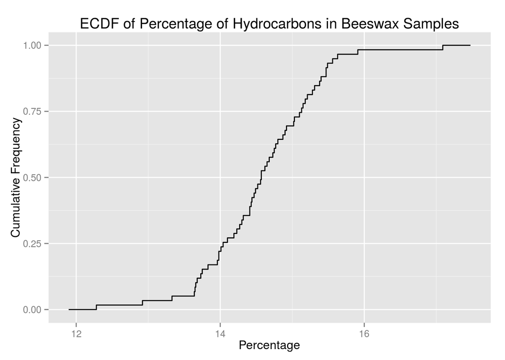

```r
hydrobject <- ggplot(wax, aes(Hydrocarbon))
hydrobject +
  stat_ecdf(geom = "step") +
  labs(title="ECDF of Percentage of Hydrocarbons in Beeswax Samples",
       x='Percentage',y='Cumulative Frequency')
```

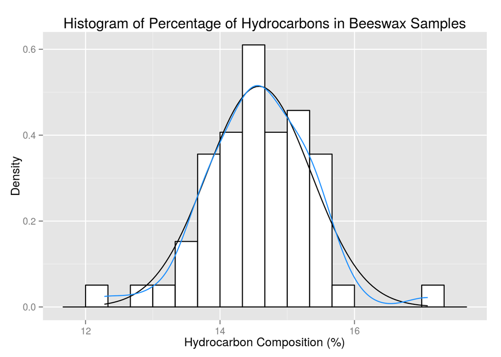

```r
hydrobject +
  geom_histogram(mapping=aes(y=..density..),color="black", fill = "white", binwidth=1/3) +
  stat_function(fun=dnorm, args=list(mean=mean(wax$Hydrocarbon), sd=sd(wax$Hydrocarbon))) +
  geom_line(mapping=aes(color="Hydro Density"), stat="density", color='dodgerblue') +
  labs(title="Histogram of Percentage of Hydrocarbons in Beeswax Samples",
    x='Hydrocarbon Composition (%)',y='Density')
```

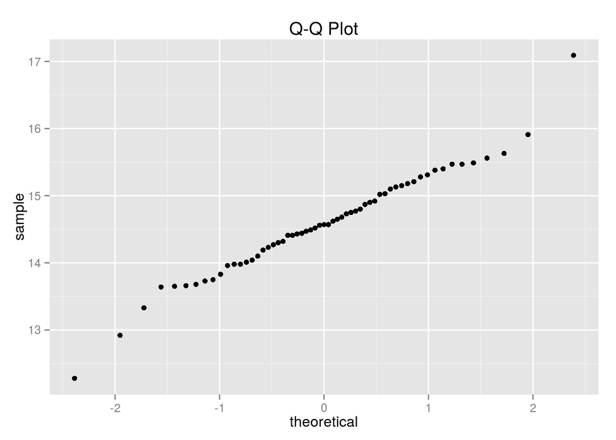

```r
ggplot(wax, aes(sample=Hydrocarbon)) +
  stat_qq() +  labs(title="Q-Q Plot")
```

```r
quantile(wax$Hydrocarbon, c(.1, .25, .5, .75, .9))
```

```
##    10%    25%    50%    75%    90%
## 13.676 14.070 14.570 15.115 15.470
```

The graphs make the data appear to be normally distributed.

### 6b.

The average percentage of hydrocarbons in microcrystalline wax (a synthetic commercial wax) is 85%. Suppose that beeswax was diluted with 1% microcrystalline wax. Could this be detected? What about a 3% or a 5% dilution? (Such questions were one of the main concerns of the beeswax study.)

Following the Example A from the book, we can examine the effect of dilution in relation to the range of the observations.

Diluting the beeswax with 1% microcrystalline wax would race the hydrocarbon percentage by $85\cdot 0.01 = 0.85$.

```r
range(wax$Hydrocarbon)
```

```
## [1] 12.28 17.09
```

With a range of $17.09-12.28=4.81$, it would be difficult to detect the dilution if it were done to beeswax that had a low hydrocarbon composition.

There is one large outlier, at 17.09. The next largest value is 15.91. If we were to subtract 0.85 from 15.91,

```r
sum(wax$Hydrocarbon < (sort(wax$Hydrocarbon)[58]-0.85))
```

```
## [1] 43
```

we could dilute 43 of the samples, and their hydrocarbon percentage would still be less than the second largest value

Diluting the beeswax with 3% microcrystalline wax would race the hydrocarbon percentage by $85\cdot 0.03 = 2.55$. Using the same approach,

```r
sum(wax$Hydrocarbon < (sort(wax$Hydrocarbon)[58]-2.55))
```

```
## [1] 3
```

we find that are only 3 samples that could be diluted that would still have a lower hydrocarbon percentage than the second largest value. The likelihood of detection would be relatively high.

Diluting the beeswax with 5% microcrystalline wax would race the hydrocarbon percentage by $85\cdot 0.05 = 4.25$. This dilution would be easy to detect.

### 10.

Let $X_1, ..., X_n$ be a sample from cdf $F$ and denote the order statistics by $X_{(1)}, X_{(2)}, ..., X_{(n)}$. We will assume that $F$ is continuous, with density function $f$. From Theorem A in Section 3.7, the density function of $X_{(k)}$ is $f_k(x)=n\binom{n-1}{k-1}[F(x)]^{k-1}[1-F(x)]^{n-k}f(x)$

### 10a.

Find the mean and variance of $X_{(k)}$ from a uniform distribution on $[0,1]$. You will need to use the fact that the density of $X_{k}$ integrates to 1. Show that $\begin{aligned} \text{Mean} &= \frac{k}{n+1} \\ \text{Variance} &= \frac{1}{n+2}\bigg(\frac{k}{n+1}\bigg)\bigg(1-\frac{k}{n+1}\bigg) \end{aligned}$

For $U[0,1]$, $f(x)=1$. So $\begin{aligned} f_k(x) &= n\binom{n-1}{k-1}[F(x)]^{k-1}[1-F(x)]^{n-k}\cdot 1 \\ &= n\frac{(n-1)!}{(k-1)!(n-k)!}[F(x)]^{k-1}[1-F(x)]^{n-k} \\ &= n\frac{\Gamma(n)}{\Gamma(k)\Gamma(n-k+1)}[F(x)]^{k-1}[1-F(x)]^{n-k} \\ &= n\frac{\Gamma(n+1)}{n\Gamma(k)\Gamma(n-k+1)}[F(x)]^{k-1}[1-F(x)]^{(n-k+1)-1} \\ &= \frac{\Gamma(n+1)}{\Gamma(k)\Gamma(n-k+1)}[F(x)]^{k-1}[1-F(x)]^{(n-k+1)-1} \\ \end{aligned}$ This resembles the beta distribution, $B(\alpha,\beta)$, where $\mu=\frac{\alpha}{\alpha+\beta}$ and $\sigma^2=\frac{\alpha\beta}{(\alpha+\beta)^2(\alpha+\beta+1)}$.

So $\mu = \frac{k}{n+1}$ and $\begin{aligned} \sigma^2 &= \frac{k(n-k+1)}{(n+1)^2(n+2)} \\ &= \frac{1}{n+2}\frac{k}{n+1}\frac{n+1-k}{n+1} \\ &= \frac{1}{n+2}\frac{k}{n+1}\bigg(\frac{n+1}{n+1}-\frac{k}{n+1}\bigg)\\ &= \frac{1}{n+2}\bigg(\frac{k}{n+1}\bigg)\bigg(1-\frac{k}{n+1}\bigg)\\ \end{aligned}$

### 10b.

Find the approximate mean and variance of $Y_{(k)}$, the *k*th-order statistic of a sample of size $n$ from $F$. To do this, let $X_i=F(Y_i)$ or $Y_i=F^{-1}(X_i)$ The $X_i$ are a sample from a $U[0,1]$ distribution (why?). Use the propagation of error formula, $\begin{aligned} Y_{(k)} &= F^{-1}(X_{(k)}) \\ &\approx F^{-1} \bigg(\frac{k}{n+1}\bigg)+\bigg(X_{(k)}-\frac{k}{n+1}\bigg)\frac{d}{dx}F^{-1}(x)\bigg|_{k/(n+1)} \end{aligned}$ and argue that $\begin{aligned} E(Y_{(k)}) &\approx F^{-1}\bigg(\frac{k}{n+1}\bigg) \\ \text{Var}(Y_{(k)}) &\approx \frac{k}{n+1}\bigg(1-\frac{k}{n+1}\bigg)\frac{1}{(f\{F^{-1}[k/(n+1)]\})^2}\bigg(\frac{1}{n+2}\bigg) \end{aligned}$

In finding the mean of the approximate value of $Y_{(k)}$, we note that many of the terms are constants: $\begin{aligned} E\big(Y_{(k)}) &\approx E\Bigg[F^{-1} \bigg(\frac{k}{n+1}\bigg)+\bigg(X_{(k)}-\frac{k}{n+1}\bigg)\frac{d}{dx}F^{-1}(x)\bigg|_{k/(n+1)}\Bigg] \\ &= E\bigg[F^{-1} \bigg(\frac{k}{n+1}\bigg)\bigg] + E\bigg[\bigg(X_{(k)}-\frac{k}{n+1}\bigg)\frac{d}{dx}F^{-1}(x)\bigg|_{k/(n+1)}\bigg] \\ &= F^{-1} \bigg(\frac{k}{n+1}\bigg) + \frac{d}{dx}F^{-1}(x)\bigg|_{k/(n+1)}\cdot E\bigg[X_{(k)}-\frac{k}{n+1}\bigg] \\ &= F^{-1} \bigg(\frac{k}{n+1}\bigg) + \frac{d}{dx}F^{-1}(x)\bigg|_{k/(n+1)}\cdot 0 \\ &= F^{-1} \bigg(\frac{k}{n+1}\bigg) \end{aligned}$  
Note that $E\big[X_{(k)}-k/(n+1)\big]=0$ since it is essentially expressing the property $E(X-\mu_X)=0$.

To solve for $\text{Var}(Y_{(k)})$, we require taking the derivative of an inverse function: $\frac{d}{dx}f^{-1}(x)=\frac{1}{\frac{d}{dx}f(f^{-1}(x))}$ Also, we will use the property $\text{Var}(aX+b)=a^2\text{Var}(X)$ So $\begin{aligned} \text{Var}(Y_{(k)}) &= \text{Var}\Bigg[F^{-1} \bigg(\frac{k}{n+1}\bigg)+\bigg(X_{(k)}-\frac{k}{n+1}\bigg)\frac{d}{dx}F^{-1}(x)\bigg|_{k/(n+1)}\Bigg] \\ &= \text{Var}\Bigg[\bigg(X_{(k)}-\frac{k}{n+1}\bigg)\frac{d}{dx}F^{-1}(x)\bigg|_{k/(n+1)}\Bigg] \\ &= \bigg(\frac{d}{dx}F^{-1}(x)\bigg|_{k/(n+1)}\bigg)^2\text{Var}\bigg(X_{(k)}-\frac{k}{n+1}\bigg) \\ &= \bigg(\frac{d}{dx}F^{-1}(x)\bigg|_{k/(n+1)}\bigg)^2\text{Var}(X_{(k)}) \\ &= \frac{1}{\Big(\frac{d}{dx}F(F^{-1}(x))\Big|_{k/(n+1)}\Big)^2}\text{Var}(X_{(k)}) \\ &= \frac{1}{\Big(f\{F^{-1}(x)\}\Big|_{k/(n+1)}\Big)^2}\text{Var}(X_{(k)}) \\ &= \frac{1}{(f\{F^{-1}(k/(n+1)\})^2}\text{Var}(X_{(k)}) \\ &= \frac{1}{(f\{F^{-1}(k/(n+1)\})^2}\frac{1}{n+2}\bigg(\frac{k}{n+1}\bigg)\bigg(1-\frac{k}{n+1}\bigg) \end{aligned}$

### 10c.

Use the results of parts (a) and (b) to show that the variance of the *p*th sample quantile is approximately $\frac{1}{nf^2(x_p)}p(1-p)$ where $x_p$ is the *p*th quantile.

I’d rather not do this problem.

### 10d.

Use the result of part (c) to find the approximate variance of the median of a sample of size *n* from a $N(\mu, \sigma^2)$ distribution. Compare to the variance of the sample mean.

The pdf of the normal distribution $f(x) = \frac{1}{\sigma\sqrt{2\pi}}\exp\bigg(-\frac{(x-\mu)^2}{2\sigma^2}\bigg)$

In a normal distribution, the median is equal to the mean, and $p=0.5$.

Then using the formula in 10c, $\begin{aligned} \frac{1}{nf^2(x_p)}p(1-p) &= \frac{1}{n\frac{1}{(\sigma\sqrt{2\pi})^2}}0.5(1-0.5) \\ &= \frac{2\sigma^2\pi}{4n} \\ &= \frac{\sigma^2\pi}{2n} \end{aligned}$

A simulation

```r
set.seed(123)
trials <- 10000
n <- 100
x<-numeric(trials)
for (i in 1:trials){
  x[i] <- median(rnorm(n)) # mu=0, sigma=1
}
var(x) # simulated variance
```

```
## [1] 0.01555409
```

```r
1*pi/(2*n) # estimated variance
```

```
## [1] 0.01570796
```

In comparison to the sample mean, $\text{Var}(\overline{X})=\frac{\sigma^2}{n}$, we see that the variance of the sample median is slightly larger.

### 11.

Calculate the hazard function for $F(t)=1-e^{-\alpha t^{\beta}}, \ \ \ t\geq 0$

The hazard function is defined as $h(t)=\frac{f(t)}{1-F(t)}$

The pdf of our provided cdf is $\begin{aligned} f(t) &= F'(t) \\ &= 0 - e^{-\alpha t^{\beta}}(-\alpha \beta)t^{\beta-1} \\ &= \alpha \beta e^{-\alpha t^{\beta}}t^{\beta-1} \end{aligned}$

So the hazard function is

$\begin{aligned} h(t) &= \frac{\alpha \beta \exp\big(-\alpha t^{\beta}\big)t^{\beta-1}}{1-\big[1-\exp\big(-\alpha t^{\beta}\big)\big]} \\ &= \frac{\alpha \beta \exp\big(-\alpha t^{\beta}\big)t^{\beta-1}}{\exp\big(-\alpha t^{\beta}\big)} \\ &= \alpha \beta t^{\beta-1} \end{aligned}$

### 15.

A prisoner is told that he will be released at a time chosen uniformly at random within the next 24 hours. Let $T$ denote the time that he is released. What is the hazard function for $T$? For what values of $t$ is it smallest and largest? If he has been waiting for 5 hours, is it more likely that he will be released in the next few minutes than if he has been waiting for 1 hour?

pdf: $f(t)=\frac{1}{24}$  
cdf: $F(t)=\frac{t}{24}$

Hazard function: $\begin{aligned} h(t) &= \frac{\frac{1}{24}}{1-\frac{t}{24}} \\ &= \frac{1}{24-t} \end{aligned}$

### 29.

Of the 26 measurements of the heat of sublimation of platinum, 5 are outliers (see Figure 10.10). Let $N$ denote the number of these outliers that occur in a bootstrap sample (sample with replacement) of the 26 measurements.

### 29a.

Explain why the distribution of $N$ is binomial.

If $N$ denotes the number of outliers, each measurement is considered an outlier or not an outlier. Therefore, each observation is a Bernoulli random variable, and $N$ is binomially distributed.

### 29b.

Find $P(N \geq 10)$.

Based on our data, $p=5/26$.

The probability that $N=x$ is given by the binomial pdf: $P(N=x) = \binom{26}{n}\bigg(\frac{5}{26}\bigg)^x\bigg(1-\frac{5}{26}\bigg)^{26-x}$

We can use the `pbinom()` function in `R` to determine $P(N \geq 10)$:

```r
pbinom(q=9, size=26, prob=5/26, lower.tail=FALSE)
```

```
## [1] 0.01787622
```

### 29c.

In 1000 bootstrap samples, how many would you expect to contain 10 or more of these outliers? (Also, run a bootstrap to compare.)

```r
# Smallest outlier in sample:
threshold <- sort(platinum, decreasing=TRUE)[5]
set.seed(123)
mean(replicate(n=100, expr=sum(replicate(n=1000, expr=sum(sample(x=platinum, size=length(platinum), replace=TRUE)>= threshold) >= 10))))
```

```
## [1] 18.55
```

### 29d.

What is the probability that a bootstrap sample is composed entirely of these outliers?

With a 5/26th chance that any given observation is an outlier, the projected probability that an entire sample is entirely composed of outliers is $\bigg(\frac{5}{26}\bigg)^{26} = 2.420544 \times 10^{-19}$